# Coronavirus country report - Germany

B.A.N.N.Wimalarathne - AS2021368

#### **Introduction of Germany**

> Germany, officially known as the Federal Republic of Germany, is a leading nation located in Central Europe. Bordered by nine countries, it stands as a vital economic and political hub within the continent. With a population exceeding 83 million people as of 2023, Germany is the most populous country in the European Union. Its central location, combined with its efficient transportation infrastructure, has made it a pivotal hub for trade and commerce. The country’s commitment to education and research has fostered a knowledge-based economy, resulting in significant contributions to technological advancements.

#### **Geographical Location**

> Its capital city, Berlin, is renowned for its historical significance and cultural vibrancy, while other major cities like Munich, Hamburg, and Frankfurt contribute to the country’s dynamic economic landscape. As a federal republic composed of 16 states, Germany boasts a diverse geographical and demographic makeup. Germany shares its borders with nine countries, making it one of the most interconnected nations in Europe.

#### **These neighboring countries are:**

- Denmark to the north
- Poland and the Czech Republic to the east
- Austria and Switzerland to the south
- France to the southwest
- Luxembourg, Belgium, and the Netherlands to the west

##### **Capital City**

- Berlin

##### **Currency**

- Euro (€) (EUR)

##### **Official Languages**

- German

##### **Demonym(s)**

- German

##### **Area**

- 357,569 km2

##### **Population**

- 84.6 million

##### **Country Code**

- +49 or 0049

##### **Religions**

- Christians (50.7%)
- No religion (43.8%)
- Eastern Orthodoxy (2.2%)
- Islam (3.7%)
- Other religions (1.7%)

#### **Economic Overview**

> Germany boasts the largest economy in Europe and the fourth largest in the world by nominal GDP. It is a global leader in various industries, including automotive manufacturing, engineering, chemicals, and pharmaceuticals. The country’s economic strength is underpinned by its robust industrial base, advanced infrastructure, and highly skilled workforce. Germany’s commitment to innovation and research and development is evident in its strong emphasis on technological advancements and its thriving startup ecosystem.

#### **Education and Healthcare**

> The country is known for its high-quality education system and is home to some of the world’s leading universities and research institutions. Additionally, Germany offers a comprehensive healthcare system that ensures universal health coverage for its citizens, contributing to high life expectancy and well-being.

## **COVID-19 pandemic in Germany**

> Germany, like many other countries, has been significantly impacted by the COVID-19 pandemic. Since the first confirmed case in January 2020, the country has navigated through multiple waves of infections, implementing various public health measures to mitigate the spread of the virus. This report provides a detailed examination of the COVID-19 situation in Germany, highlighting key statistics, government responses, and the socio-economic impact of the pandemic.

#### **Initial Outbreak and Spread**

> The initial outbreak of COVID-19 in Germany was reported on January 27, 2020, when a case was confirmed in Bavaria. The virus quickly spread, leading to the implementation of nationwide measures to control the epidemic. Germany’s early response was characterized by extensive testing, contact tracing, and the establishment of quarantine protocols.

## **Exploratory Data Analysis**

A data frame with following variables.

**date :** Date in YYYY-MM-DD format.

**province :** Name of province/state.

**country :** Name of the country.

**lat :** Latitude of center of geographic region.

**long :** Longitude of center of geographic region.

**type :** An indicator for the type of cases (confirmed, death, recovery).

**cases :** Number of cases on given date.

**uid :** Country code

**iso2 :** Officially assigned country code identifiers with two-letter

**iso3 :** Officially assigned country code identifiers with three-letter

**code3 :** UN country code

**combined_key :** Country and province (if applicable)

**population :** Country or province population

**continent_name :** Continent name

**continent_code :** Continent code

### **Distribution of Covid-19 in Germany**

#### **Summary about the Filtered Germany Corona Dataset**

```
##       date              province           country               lat
##  Min.   :2020-01-22   Length:3429        Length:3429        Min.   :51.17
##  1st Qu.:2020-11-02   Class :character   Class :character   1st Qu.:51.17
##  Median :2021-08-15   Mode  :character   Mode  :character   Median :51.17
##  Mean   :2021-08-15                                         Mean   :51.17
##  3rd Qu.:2022-05-28                                         3rd Qu.:51.17
##  Max.   :2023-03-09                                         Max.   :51.17
##       long           type               cases             uid
##  Min.   :10.45   Length:3429        Min.   : -4320   Min.   :276
##  1st Qu.:10.45   Class :character   1st Qu.:     0   1st Qu.:276
##  Median :10.45   Mode  :character   Median :   187   Median :276
##  Mean   :10.45                      Mean   : 12271   Mean   :276
##  3rd Qu.:10.45                      3rd Qu.:  4210   3rd Qu.:276
##  Max.   :10.45                      Max.   :484345   Max.   :276
##      iso2               iso3               code3     combined_key
##  Length:3429        Length:3429        Min.   :276   Length:3429
##  Class :character   Class :character   1st Qu.:276   Class :character
##  Mode  :character   Mode  :character   Median :276   Mode  :character
##                                        Mean   :276
##                                        3rd Qu.:276
##                                        Max.   :276
##    population       continent_name     continent_code
##  Min.   :83783945   Length:3429        Length:3429
##  1st Qu.:83783945   Class :character   Class :character
##  Median :83783945   Mode  :character   Mode  :character
##  Mean   :83783945
##  3rd Qu.:83783945
##  Max.   :83783945
```

This is the summary about filtered data set Germany from the coronavirus data set. So can see in cases column there are minus values. Cases cannot be minus. They are outliers. So, we can do some statistical things to avoid this error. The data set has data from 2020-01-22 to 2023-03-09. According to the above summary we can see the mean number of cases are 12271. The maximum number of cases are 484345.

#### **Confirmed Corona Cases in Germany**

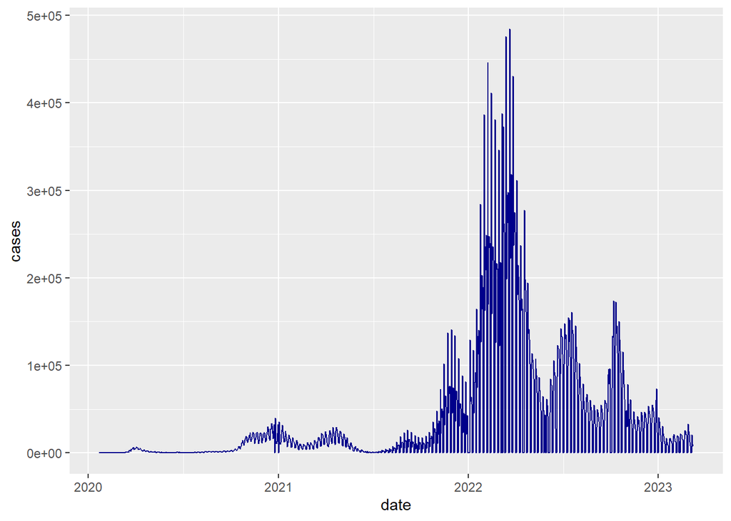

In the above Figure, we can see that there is high confirmed cases in first months of 2022. From 2023 the confirmed cases are decreased. In here there are no missing values or null values.

#### **Recovery Corona Cases in Germany**

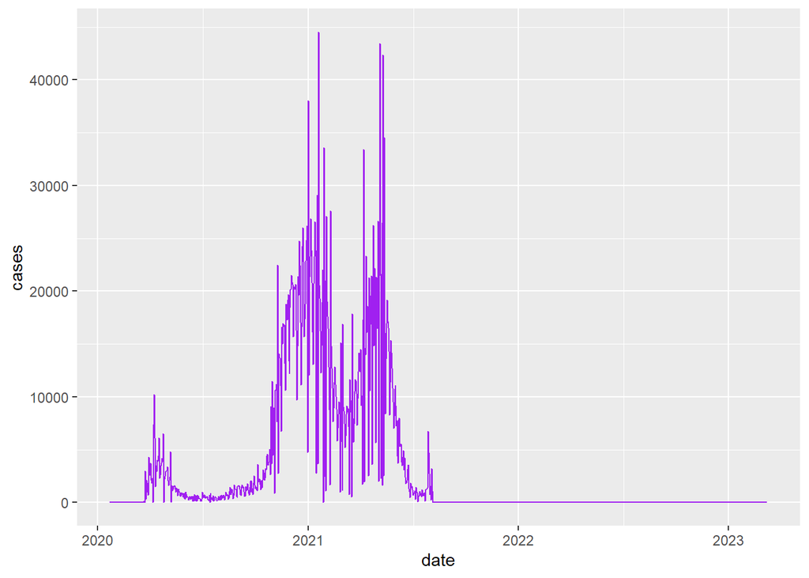

In the above figure from 2020 - 2021 the recovery cases are increased.In 2021 year firstly recovery cases are decreased and again it get increased.

#### **Death Corona Cases in Germany**

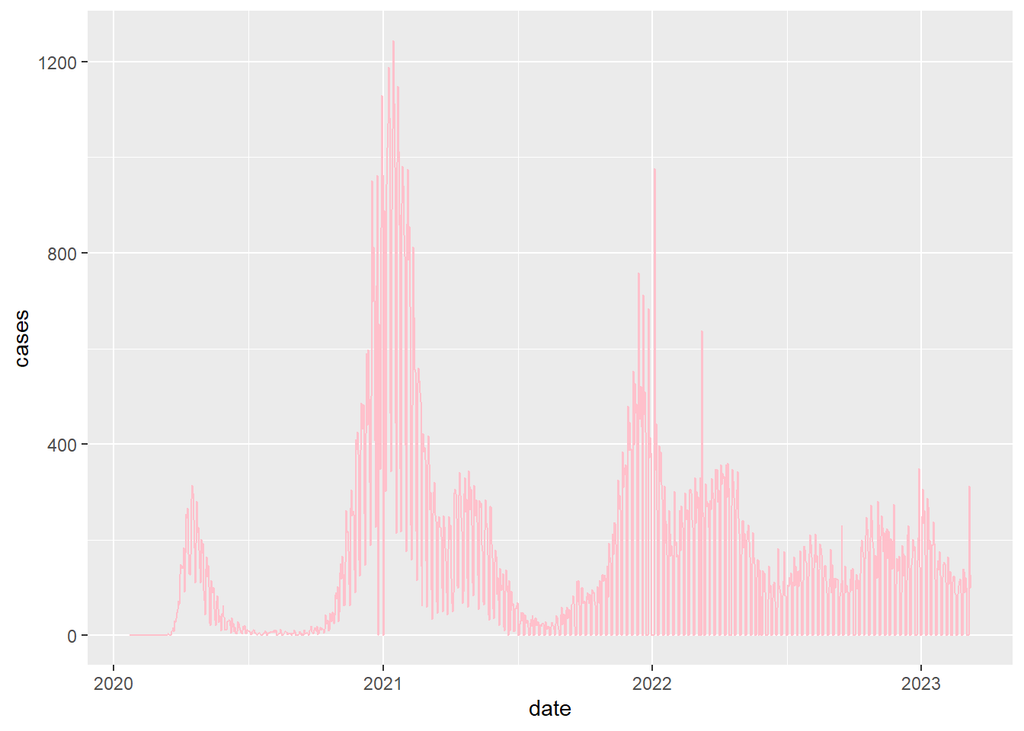

#### **Active Cases In Germany**

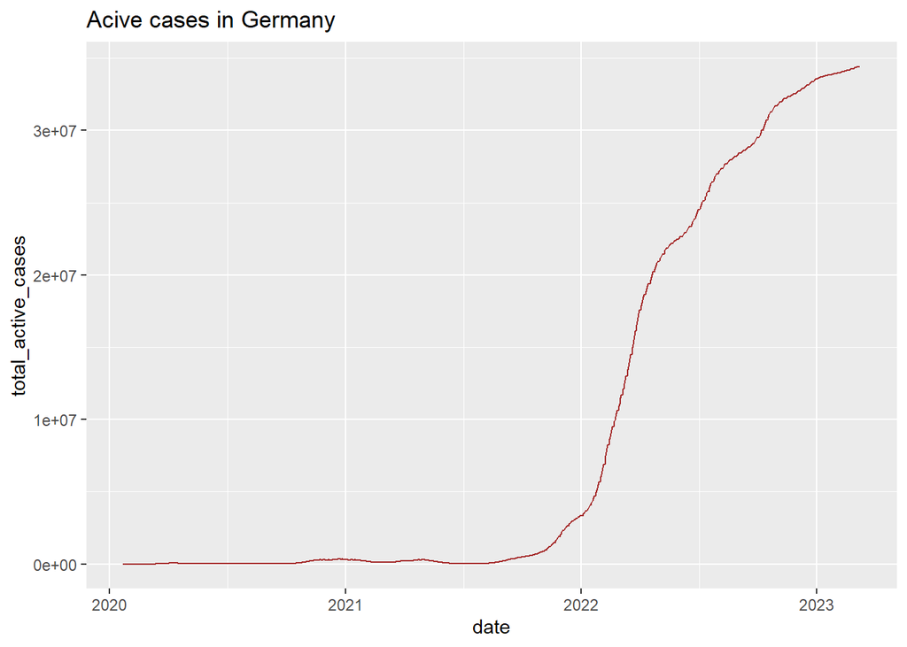

According to the graph we can conclude that most of active cases are between mid 2022 to early 2023.

#### **Compare Confirmed Cases with France,Belgium and Poland**

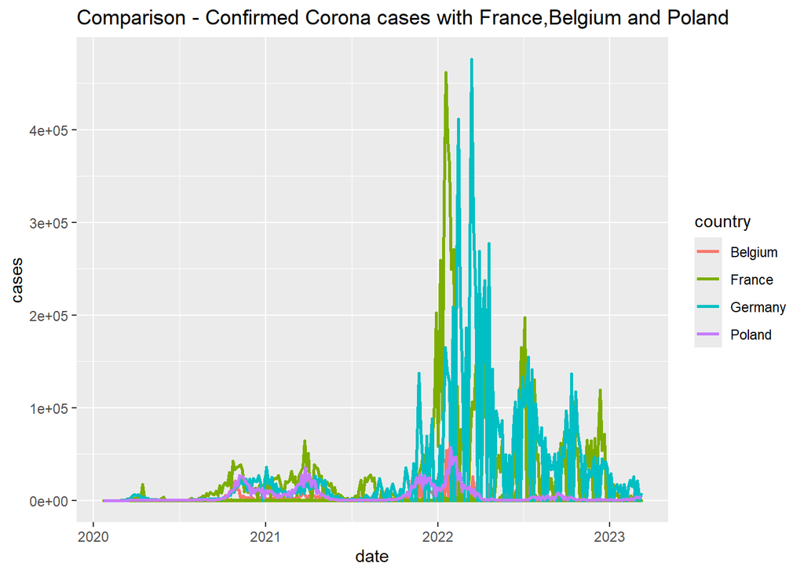

#### **Compare Recovery Cases with France,Belgium and Poland**

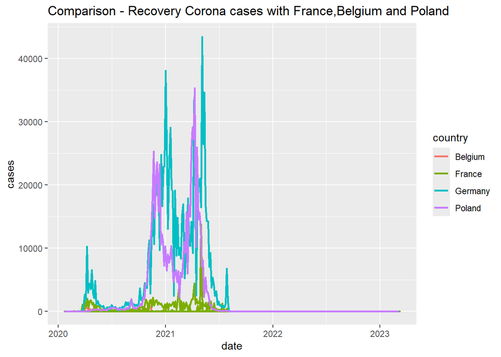

#### **Compare Death Cases with France,Belgium and Poland**

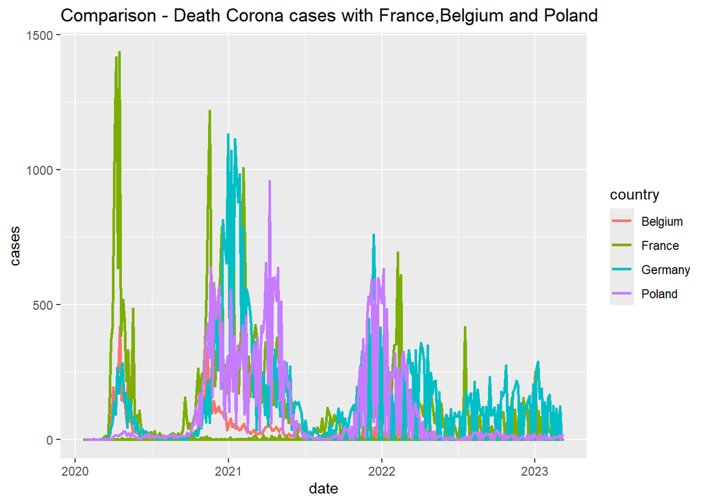

According to the Figure, we can say that France has the highest death corona cases. As well as Belgium has the lowest death corona cases.Poland also has considerable death cases.

#### **All Confirmed, Recovery and Death cases**

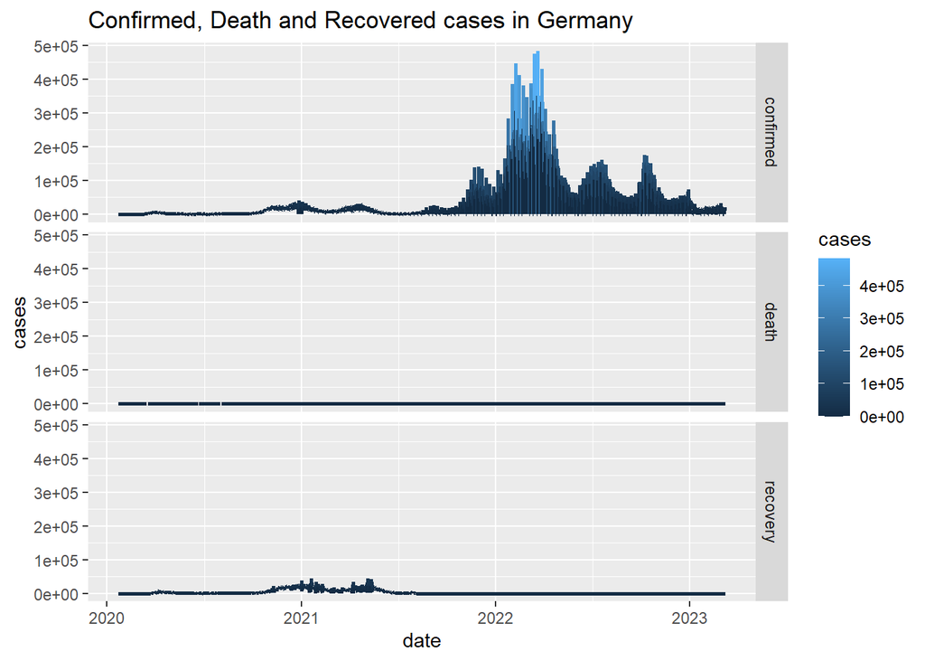

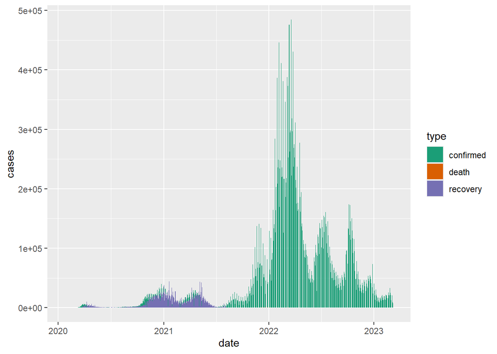

According to the this figure we can see the death are very lover than confirmed and recovery cases. That is good thing. Between 2022-2023 have the maximum confirmed cases.

#### **References**

- [Introduction about Germany](https://en.wikipedia.org/wiki/Germany)